# Attainment and Attendance in Mid Sussex

What the national model behind *How to Pull the Right Lever* says about the district’s secondary schools, within West Sussex and alongside Brighton and Hove. **Draft for discussion.**

Author

Affiliation

Adam Dennett

Bartlett Centre for Advanced Spatial Analysis, University College London

Published

October 31, 2026

**WarningDraft for discussion**

One of the district documents for Sussex. It sits beneath the West Sussex document, and the district summary compares all of the districts. Every figure comes from published Department for Education data and the national models of [How to Pull the Right Lever](https://adamdennett.github.io/school_attainment_tool/pulling_the_right_lever_v2.html). Nothing uses pupil-level records.

# Summary

**Mid Sussex is one of the most advantaged school districts in England, and its disadvantaged pupils do not share in that advantage.** Its 7 state secondary schools in Burgess Hill, Haywards Heath, East Grinstead and Hassocks are mostly high-performing:

- **Overall results are high:** 50.3 in Attainment 8 in 2024-25, 53rd of 264 districts in England with five or more schools.
- **Few pupils are disadvantaged:** 12.2%, against 28.3% nationally.
- **Disadvantaged pupils average 35.5**, below the national 37.8 (155th of 264).
- **The gap between the two groups is 16.9 points**, the 18th widest of any district.

The other findings:

- **The model explains most of the overall advantage.** Low disadvantage, high prior attainment and good attendance lift Mid Sussex well above England. Its schools add a little more on top.
- **For disadvantaged pupils the picture reverses.** West Sussex’s county-wide effect and the South East’s regional effect cost them 2.8 points. Mid Sussex’s schools then fall a further 1.2 points below expectation for these pupils, while sitting above expectation overall.
- **It is a school-level pattern, not a district one.** No Mid Sussex district effect can be found. Oathall and Warden Park are above expectation overall and well below for their disadvantaged pupils. Downlands is strong for both.
- **Attendance is good, but three schools run more absence than their intakes predict:** Imberhorne, Sackville and The Burgess Hill Academy. As in the rest of West Sussex, reduced timetables run at nearly twice the national rate.
- **Disadvantaged groups are small,** 14 to 40 pupils a year per school. Every school-level figure for them moves by several points from year to year and should be read over several years.

# 1 About this analysis

Mid Sussex is a district of West Sussex, not a local authority, and that shapes what can be said:

- **The national models place schools in local authorities.** The “local authority effect” in this document is West Sussex’s, shared with every school in the county.
- **What is particular to Mid Sussex** shows up in its schools’ own residuals, and in the district test of Section 6.
- **Absence and exclusions** are summed over the district’s seven schools, followed through any change of URN.

Everything else is as in the East Sussex and West Sussex documents, which describe the methods in full.

# 2 The district’s schools

[interactive chart not shown]

Mid Sussex’s state-funded secondary schools, coloured by overall absence in 2024/25. Choose another measure from the menu above the map; circle size is the school’s roll. Hover for figures and who runs each school.

Every state-funded secondary school in Mid Sussex, 2024/25, with the size of its disadvantaged Year 11 group.

| School | Town | Type | Pupils | FSM % | Disadvantaged in Year 11 | Absence % | KS2 | Att 8 | Att 8 disadv. | Ofsted |
| --- | --- | --- | --- | --- | --- | --- | --- | --- | --- | --- |
| St Paul's Catholic College | Burgess Hill | Academy | 1190 | 7.7 | 14 | 5.8 | 6.8 | 55.4 | 42.5 | Outstanding |
| The Burgess Hill Academy | Burgess Hill | Academy | 1018 | 19.1 | 40 | 10.0 | 3.5 | 44.6 | 33.2 | Good |
| Imberhorne School | East Grinstead | Maintained | 1573 | 13.2 | 32 | 9.5 | 3.6 | 45.0 | 26.2 | Good |
| Sackville School | East Grinstead | Maintained | 1599 | 12.9 | 35 | 9.9 | 3.5 | 46.0 | 34.9 | Good |
| Downlands Community School | Hassocks | Maintained | 1250 | 7.4 | 17 | 7.6 | 5.7 | 57.2 | 45.7 | Good |
| Oathall Community College | Haywards Heath | Maintained | 1303 | 16.9 | 39 | 7.9 | 5.2 | 51.5 | 35.8 | Good |
| Warden Park Secondary Academy | Haywards Heath | Academy | 1538 | 8.2 | 24 | 7.7 | 6.5 | 52.3 | 30.1 | Good |

4 of the seven schools are maintained by West Sussex County Council. The other three are academies:

- **Warden Park**, in the Sussex Learning Trust;
- **St Paul’s Catholic College**, in the Bosco Catholic Education Trust;
- **The Burgess Hill Academy**, a sponsored academy that moved from the University of Brighton Academies Trust to the Sussex Learning Trust after 2024/25.

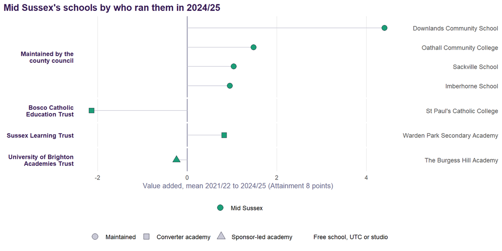

Figure 1: Who ran each Mid Sussex school in 2024/25, and how far its results sat above or below the national model’s expectation over 2021/22 to 2024/25.

# 3 How Mid Sussex compares

Mid Sussex against West Sussex, Brighton and Hove and England, 2024/25. Means of school-level figures.

| Measure | Mid Sussex | West Sussex | Brighton and Hove | England |
| --- | --- | --- | --- | --- |
| Attainment 8, all pupils | 50.3 | 46.4 | 45.5 | 46.8 |
| Attainment 8, disadvantaged | 35.5 | 33.5 | 33.9 | 37.7 |
| Attainment 8, non-disadvantaged | 52.3 | 48.9 | 49.6 | 49.9 |
| Disadvantage gap (points) | 16.9 | 15.4 | 15.7 | 12.2 |
| Disadvantaged (FSM6) % | 12.2 | 17.1 | 28.8 | 28.4 |
| Overall absence % | 8.3 | 8.7 | 11.3 | 8.6 |
| Persistent absence % | 21.3 | 23.9 | 30.6 | 23.9 |
| Mean KS2 (centred) | 4.97 | 4.26 | 4.71 | 4.47 |
| EAL % | 6.9 | 11.0 | 13.0 | 18.4 |

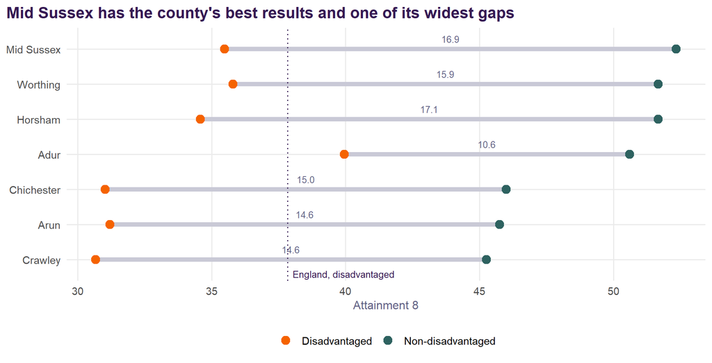

Figure 2: Attainment 8 for disadvantaged and non-disadvantaged pupils in West Sussex’s seven districts, 2024/25, school means. The gap between the two is printed on each district’s line.

The gap is not one year’s accident. It was 17.3 points in 2021/22 and 21.3 at its widest (2023-24). Mid Sussex’s non-disadvantaged pupils do better than England’s every year, and its disadvantaged pupils worse.

# 4 What explains attainment in Mid Sussex

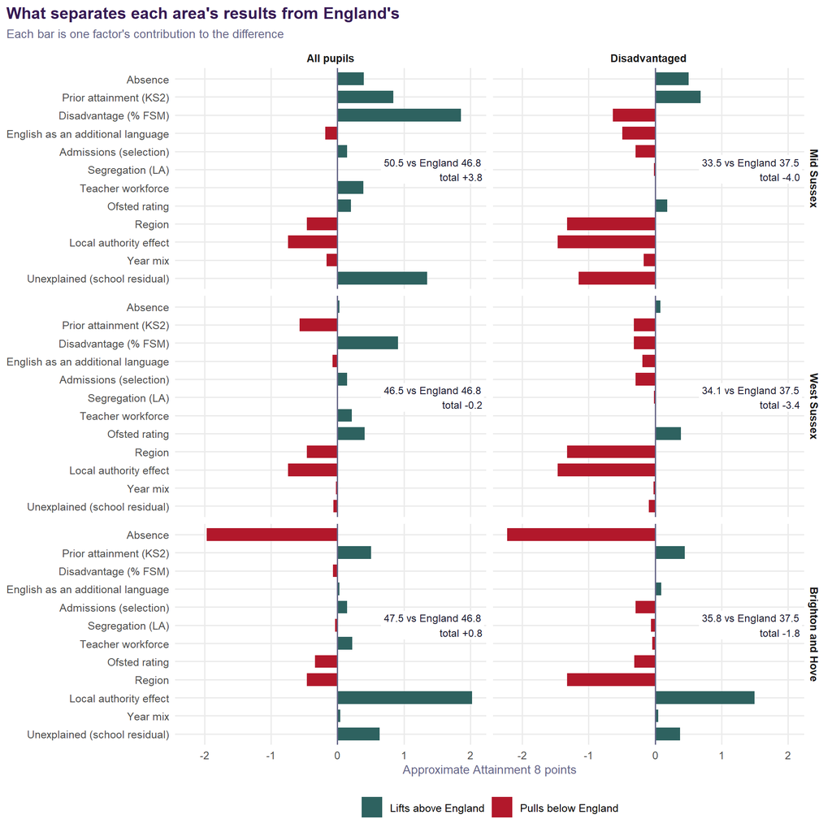

Figure 3: Why average Attainment 8 differs from England’s, by factor, all school-years 2021/22 to 2024/25, for Mid Sussex, West Sussex and Brighton and Hove. Approximate Attainment 8 points; the pieces sum to the total in each panel.

The decomposition for Mid Sussex, in Attainment 8 points. ‘Place’ is West Sussex’s effect plus the South East’s; ‘unexplained’ is what Mid Sussex’s own schools add beyond everything the model accounts for.

| Factor | All pupils | Disadvantaged | Non-disadvantaged |
| --- | --- | --- | --- |
| Place (region and local authority) | -1.20 | -2.79 | -1.48 |
| English as an additional language | -0.18 | -0.50 | -0.26 |
| Other model terms | -0.02 | -0.49 | -0.02 |
| Ofsted rating | +0.20 | +0.18 | +0.17 |
| Teacher workforce | +0.39 | +0.01 | +0.38 |
| Absence | +0.40 | +0.50 | +0.37 |
| Prior attainment (KS2) | +0.84 | +0.69 | +0.97 |
| Unexplained (school residual) | +1.35 | -1.15 | +1.64 |
| Disadvantage (% FSM) | +1.86 | -0.64 | +0.94 |

**For all pupils**, Mid Sussex is 3.8 points above England. Almost all of that is intake, and the model expects it:

- low disadvantage (+1.86);
- high prior attainment (+0.84);
- good attendance (+0.40).

The district’s schools add +1.35 on top, more than enough to offset West Sussex’s county-wide effect.

**For disadvantaged pupils** the picture reverses: Mid Sussex is 4.0 points *below* England.

- **Place** takes 2.79: West Sussex’s own effect and the South East’s.
- **The schools themselves** take a further 1.15. They are above expectation for their other pupils and below it for these.
- **Low disadvantage counts against them** too (-0.64).

That last point is the Lever report’s most contested finding showing up locally. Across England, disadvantaged pupils do slightly better in schools with more disadvantaged pupils, once everything else is accounted for. The likely reason is that such schools organise around them, and spend pupil premium on provision that a handful of pupils cannot sustain. In Mid Sussex, where a school may have twenty disadvantaged pupils in a year group, that does not happen at scale.

# 5 The disadvantaged gap, school by school

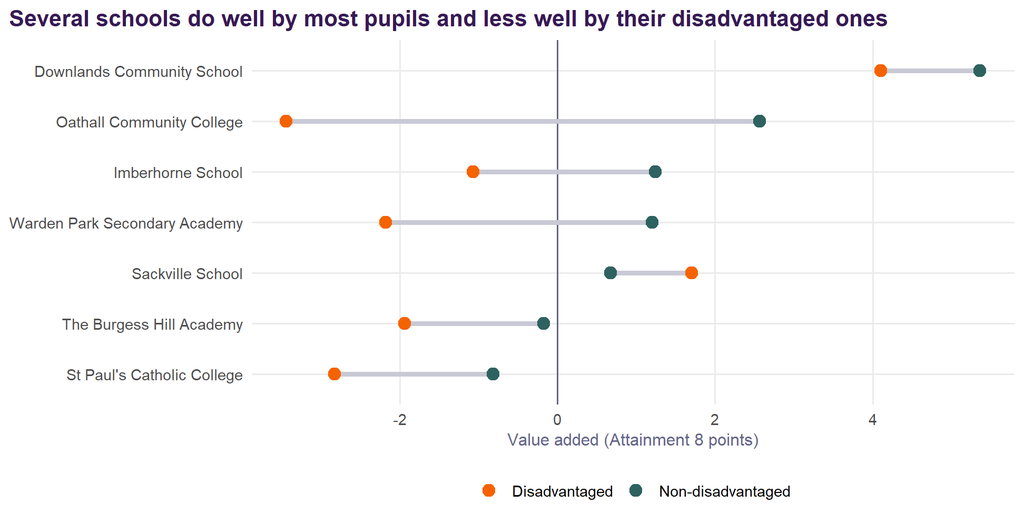

Figure 4: Each Mid Sussex school’s value added for its disadvantaged and non-disadvantaged pupils, mean over the years available (2021/22 to provisional 2025/26). Above zero means better than the national model expects for similar pupils.

3 schools are above expectation for their non-disadvantaged pupils and more than a point below it for their disadvantaged ones: Oathall Community College, Warden Park Secondary Academy, Imberhorne School. With each school’s own record in the model:

- **Oathall Community College** is +3.1% overall and -7.4% for disadvantaged pupils.
- **Warden Park** is +1.3% overall and -6.6% for disadvantaged pupils.
- **Downlands Community School** is the exception, above expectation for both groups (+7.3% and +7.7%). It has one of the district’s smallest disadvantaged groups.

Table 1: Attainment 8 of each school’s disadvantaged pupils, year by year (2025/26 provisional), with the size of the group in 2024/25. Small groups make single years unreliable.

| School | 2021/22 | 2022/23 | 2023/24 | 2024/25 | 2025/26 | Disadvantaged pupils, 2024/25 |
| --- | --- | --- | --- | --- | --- | --- |
| Downlands Community School | 36.9 | 36.3 | 39.9 | 45.7 | 41.2 | 17 |
| Imberhorne School | 38.5 | 35.1 | 23.0 | 26.2 | 33.9 | 32 |
| Oathall Community College | 33.0 | 31.9 | 28.5 | 35.8 | 37.2 | 39 |
| Sackville School | 39.6 | 35.9 | 24.0 | 34.9 | 37.3 | 35 |
| Warden Park Secondary Academy | 37.9 | 32.3 | 33.0 | 30.1 | 42.1 | 24 |
| The Burgess Hill Academy |  |  | 28.5 | 33.2 | 27.5 | 40 |
| St Paul's Catholic College |  |  | 33.2 | 42.5 | 40.9 | 14 |

With groups this small, any one school-year can move by ten points. Imberhorne and Sackville’s disadvantaged results fell sharply in 2023/24 and recovered after. The pattern that matters is the one across years and schools, and it is consistent: the district’s disadvantaged pupils do less well than its other pupils, by more than they do in similar schools elsewhere.

# 6 Is there a Mid Sussex effect?

The district test of the East Sussex document adds a district level to the national model, with and without each school’s own record.

Table 2: The Mid Sussex district effect, over and above West Sussex’s, with 95% intervals.

| Specification | Outcome | Effect (%) | 95% interval | Significant |
| --- | --- | --- | --- | --- |
| Published specification | All pupils | +1.6 | -1.7 to +5.0 | No |
| Published specification | Disadvantaged | -2.5 | -6.2 to +1.4 | No |
| Published specification | Non-disadvantaged | +1.9 | -0.9 to +4.8 | No |
| Published specification | Absence (stage 1) | +3.6 | -3.3 to +11.0 | No |
| With a school term | All pupils | +0.6 | -2.6 to +3.9 | No |
| With a school term | Disadvantaged | -0.9 | -3.9 to +2.2 | No |
| With a school term | Non-disadvantaged | +1.1 | -2.2 to +4.4 | No |
| With a school term | Absence (stage 1) | +0.2 | -5.4 to +6.1 | No |

None of Mid Sussex’s district effects can be told apart from zero on either specification. The district’s results are explained by its intake, West Sussex’s county effect and its individual schools, which differ a good deal. Unlike Crawley, the West Sussex district where every school is below expectation, there is nothing that all Mid Sussex schools share.

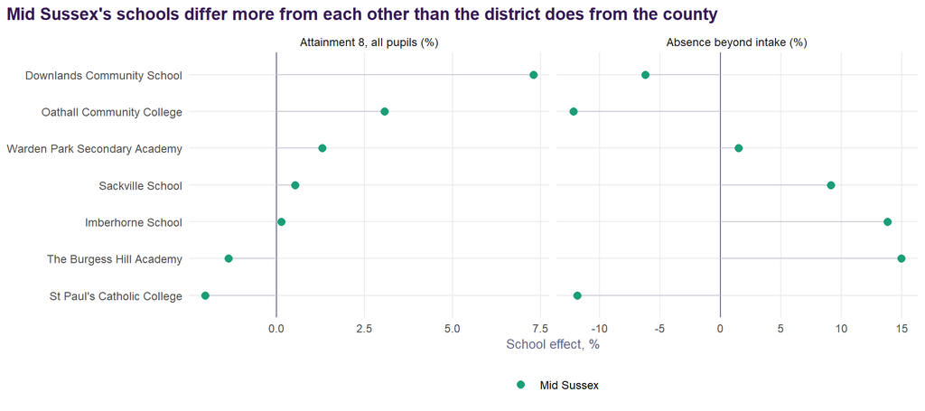

Figure 5: Each Mid Sussex school’s own persistent effect, from the model with a school term: Attainment 8 for all pupils, and absence beyond what its intake predicts.

# 7 Absence

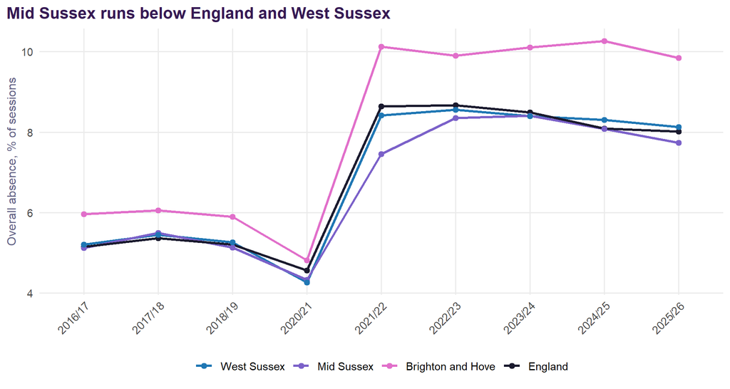

Figure 6: Overall absence, autumn and spring terms, 2016/17 to 2025/26. Sessions-weighted; 2019/20 not collected.

Attendance in Mid Sussex is good:

- **7.7% absence** in autumn and spring 2025/26, against 8.0% for England and 8.1% for West Sussex.
- **Persistent absence** is 18.8%.

The district’s intake predicts lower absence still. Its schools run +0.41 points above what their pupils’ profiles predict, but the excess is concentrated in three schools:

Table 3: Each school’s absence against what its intake predicts, mean 2021/22 to 2024/25, and its reasons in the latest year (percentage of sessions).

| School | Absence % | Predicted by intake % | Above prediction | Illness | Unauthorised | Reduced timetable | Suspended |
| --- | --- | --- | --- | --- | --- | --- | --- |
| The Burgess Hill Academy | 10.3 | 8.8 | +1.5 | 3.2 | 3.1 | 0.50 | 0.23 |
| Imberhorne School | 9.8 | 8.3 | +1.5 | 3.9 | 2.2 | 0.24 | 0.14 |
| Sackville School | 9.4 | 8.3 | +1.1 | 4.5 | 2.2 | 0.67 | 0.06 |
| Warden Park Secondary Academy | 8.0 | 7.5 | +0.4 | 3.2 | 2.3 | 0.24 | 0.07 |
| Downlands Community School | 7.5 | 7.8 | -0.2 | 4.8 | 1.0 | 0.56 | 0.24 |
| St Paul's Catholic College | 6.2 | 6.6 | -0.4 | 3.4 | 1.2 | 0.30 | 0.05 |
| Oathall Community College | 7.4 | 8.4 | -1.0 | 3.9 | 1.4 | 1.19 | 0.13 |

- **The Burgess Hill Academy, Imberhorne and Sackville** each run more than a point above their predicted absence.
- **Oathall and St Paul’s** run below theirs.

As across West Sussex, reduced timetables are used at about twice the national rate: 0.54% of sessions against 0.29%. Oathall’s rate is the highest in the district.

Table 4: Predicted Attainment 8 gain if each school’s absence fell to the national school average (2024/25). Indicative only.

| School | District | Absence % | FSM % | Gain, all pupils | Gain, disadvantaged | Gain from FSM to area average |
| --- | --- | --- | --- | --- | --- | --- |
| The Burgess Hill Academy | Mid Sussex | 10.0 | 19.1 | +1.4 | +1.6 | +1.0 |
| Sackville School | Mid Sussex | 9.9 | 12.9 | +1.4 | +1.5 | +0.1 |
| Imberhorne School | Mid Sussex | 9.5 | 13.2 | +1.0 | +0.8 | +0.2 |
| Oathall Community College | Mid Sussex | 7.9 | 16.9 | +0.0 | +0.0 | +0.8 |

Only three schools are above the national average absence, and the gains from bringing them to it are modest: up to 1.4 points. Attendance is not Mid Sussex’s lever.

**Suspensions** are well below the national rate: 12.5 per 100 pupils in 2024/25, against 21.2 for England and 16.2 for West Sussex. The rate varies widely between schools:

Table 5: Suspensions per 100 pupils and permanent exclusions, by school, latest year.

| School | Pupils | Suspensions per 100 | Permanent exclusions |
| --- | --- | --- | --- |
| The Burgess Hill Academy | 1018 | 30.3 | 0 |
| Downlands Community School | 1250 | 20.3 | 0 |
| Oathall Community College | 1303 | 14.4 | 2 |
| Imberhorne School | 1573 | 12.0 | 1 |
| Sackville School | 1599 | 8.1 | 0 |
| St Paul's Catholic College | 1190 | 4.5 | 0 |
| Warden Park Secondary Academy | 1538 | 3.9 | 0 |

# 8 Contextual league tables

**All pupils**

Value added, all pupils: observed Attainment 8 minus the national model’s expectation. 2025/26 is provisional.

| School | 2021/22 | 2022/23 | 2023/24 | 2024/25 | 2025/26 | Mean | Years |
| --- | --- | --- | --- | --- | --- | --- | --- |
| Downlands Community School | +3.3 | +3.4 | +4.4 | +6.1 | +7.4 | +4.9 | 5 |
| Oathall Community College | -1.5 | +2.2 | +1.4 | +3.0 | +2.2 | +1.5 | 5 |
| Imberhorne School | -0.3 | +2.5 | +0.5 | +0.9 | +2.0 | +1.1 | 5 |
| Sackville School | +0.8 | +1.1 | -0.2 | +1.9 | +1.3 | +1.0 | 5 |
| Warden Park Secondary Academy | -0.1 | +1.9 | +1.8 | -0.8 | +0.7 | +0.7 | 5 |
| The Burgess Hill Academy |  |  | -2.5 | +1.9 | +0.2 | -0.1 | 3 |
| St Paul's Catholic College |  |  | -1.5 | -2.5 | -0.7 | -1.6 | 3 |

**Disadvantaged pupils**

Value added, disadvantaged pupils. Small groups; read across years.

| School | 2021/22 | 2022/23 | 2023/24 | 2024/25 | 2025/26 | Mean | Years |
| --- | --- | --- | --- | --- | --- | --- | --- |
| Downlands Community School | -0.8 | -0.4 | +5.1 | +10.9 | +5.8 | +4.1 | 5 |
| Sackville School | +2.8 | +4.2 | -7.0 | +3.7 | +4.7 | +1.7 | 5 |
| Imberhorne School | +2.8 | +2.7 | -6.6 | -4.6 | +0.5 | -1.1 | 5 |
| The Burgess Hill Academy |  |  | -2.0 | +2.1 | -5.9 | -1.9 | 3 |
| Warden Park Secondary Academy | -0.2 | -4.3 | -4.0 | -6.5 | +4.1 | -2.2 | 5 |
| St Paul's Catholic College |  |  | -7.3 | +1.1 | -2.3 | -2.8 | 3 |
| Oathall Community College | -7.7 | -3.9 | -6.6 | +0.2 | +0.8 | -3.4 | 5 |

**Non-disadvantaged pupils**

Value added, non-disadvantaged pupils.

| School | 2021/22 | 2022/23 | 2023/24 | 2024/25 | 2025/26 | Mean | Years |
| --- | --- | --- | --- | --- | --- | --- | --- |
| Downlands Community School | +4.3 | +4.4 | +4.6 | +5.8 | +7.7 | +5.4 | 5 |
| Oathall Community College | +0.2 | +3.7 | +2.3 | +3.8 | +2.8 | +2.6 | 5 |
| Imberhorne School | -0.6 | +2.3 | +0.8 | +1.5 | +2.2 | +1.2 | 5 |
| Warden Park Secondary Academy | +0.1 | +3.0 | +2.6 | -0.3 | +0.6 | +1.2 | 5 |
| Sackville School | +0.9 | +0.4 | +0.2 | +1.2 | +0.6 | +0.7 | 5 |
| The Burgess Hill Academy |  |  | -3.2 | +1.6 | +1.1 | -0.2 | 3 |
| St Paul's Catholic College |  |  | -0.4 | -2.2 | +0.2 | -0.8 | 3 |

# 9 Implications and questions for discussion

1. **The district’s issue is its disadvantaged pupils, not its schools overall.** Mid Sussex’s results are among the best of any district, and its disadvantaged pupils’ results are below the national average. That combination is the question worth putting to its schools.
2. **Small numbers need a different approach.** With 14 to 40 disadvantaged pupils in a year group, the provision that serves them well in high-disadvantage schools cannot be built school by school. Seven schools within a few miles of each other might build it together.
3. **Learn from Downlands**, which does well by both groups, and ask what Oathall and Warden Park do differently for their disadvantaged pupils.
4. **The county effect still applies.** Mid Sussex’s disadvantaged pupils carry West Sussex’s below-expectation effect too. The county question in the West Sussex document applies here as well.
5. **Attendance and suspensions** are not the district’s problem, with three schools’ absence the exception. Reduced timetables, as across West Sussex, are worth a look.

# Notes on method

Methods and sources are those of the East Sussex document. District membership comes from each school’s postcode (ONS postcode directory, via postcodes.io). Absence and exclusions for the district are summed over its schools, including any predecessor URNs. This document is built by `R/17_area_analysis.R`, `R/18_district_effects.R`, `R/19_trust_effects.R` and `mid_sussex.qmd`.